# homework_05

## Exercise

Load the national COVID dataset and solve the exercise using `scikit-learn` library. Consider first the column corresponding to the (cumulative) number of deaths.

1. Perform a train-test split, with observations from the last week corresponding to the test set;
2. Build a suitable combination of kernels choosing from the ones shown in `notebook_05`;
3. Fit a `GaussianProcessRegressor` to predict the daily number of swabs, plot future predictions and compare them to real test data;
4. Repeat points 1-3 on the daily number of swabs, which can be computed from the cumulative number provided in the dataset.

You are welcome to try out and fit other data streams in the dataset.

```python
%pylab inline
from sklearn import gaussian_process
from matplotlib import pyplot as plt
import pandas as pd

plt.rcParams['axes.titlesize'] = 20
plt.rcParams['axes.labelsize'] = 16
plt.rcParams['xtick.labelsize'] = 12
plt.rcParams['ytick.labelsize'] = 12
plt.rcParams['legend.fontsize'] = 14
```

## Swabs:

## Dataset Preparation

```python
data = pd.read_csv("https://raw.githubusercontent.com/pcm-dpc/COVID-19/master/dati-andamento-nazionale/dpc-covid19-ita-andamento-nazionale.csv")
from sklearn.preprocessing import StandardScaler
test_size = 7

#constructing data for model predicting swabs from date
raw_tamponi = data["tamponi"].values
tot_size = raw_tamponi.size

def scale(data, test_size = 7, return_scaler = False):
    tot_size = data.size
    scaler = StandardScaler()

    train_X = array(range(1, tot_size - test_size + 1))
    train_Y = data[:-test_size]
    test_X = array(range(tot_size - test_size + 1, tot_size + 1))
    test_Y = data[-test_size:]

    scaler.fit(train_Y.reshape(-1,1))
    train_Y = scaler.transform(train_Y.reshape(-1,1)).flatten()
    test_Y = scaler.transform(test_Y.reshape(-1,1)).flatten()
    if (return_scaler): return train_X, train_Y, test_X, test_Y, scaler
    return train_X, train_Y, test_X, test_Y


train_X, train_Y, test_X, test_Y = scale(raw_tamponi)
tamponi = np.hstack((train_Y,test_Y))
```

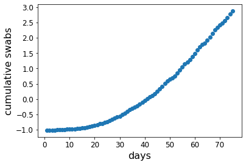

```python
plt.scatter(range(1, tot_size + 1),tamponi)
plt.xlabel("days")
plt.ylabel("cumulative swabs")
plt.show()
```

```python
from sklearn.gaussian_process.kernels import RBF, ExpSineSquared, RationalQuadratic, WhiteKernel, DotProduct
from sklearn.gaussian_process import GaussianProcessRegressor


def plot_predictions(gp, train_X,train_Y, test_X, test_Y, include_observed=True):

    x = np.hstack((train_X,test_X))
    X = x.reshape(-1,1)
    test_size = train_Y.shape[0]

    pred_y, pred_std = gp.predict(X, return_std=True)
    pred_y, pred_std = pred_y.flatten(), pred_std.flatten()
    plt.figure(figsize=(10, 7))
    if include_observed:
        plt.plot(x, list(train_Y) + list(test_Y), 'ok', alpha=0.1)
    l, = plt.plot(x, pred_y)
    plt.fill_between(x,
                     pred_y + pred_std,
                     pred_y - pred_std,
                     color=l.get_color(), alpha=0.3)
    plt.axvline(test_X[0], linestyle='--', color='k')
    plt.title(str(gp.kernel_));
    plt.show()
    pred_y, pred_std = gp.predict(test_X.reshape(-1,1), return_std=True)
    pred_y, pred_std = pred_y.flatten()[-test_size :], pred_std.flatten()[-test_size :]
    err = np.sum(((pred_y - test_Y) / pred_std) ** 2) / test_size
    print("Log Marginal Likelihood:" + str(gp.log_marginal_likelihood_value_))
    print("Average distance test-prediction in units of sigma: " + str(err))
    return


def fit_and_predict(ker, train_X,train_Y, test_X, test_Y, seed = None):
    gp = GaussianProcessRegressor(kernel=ker, alpha=0.01,
                               normalize_y=False,
                               n_restarts_optimizer=10, random_state=seed)
    gp.fit(train_X.reshape(-1,1),train_Y.reshape(-1,1))
    plot_predictions(gp, train_X,train_Y, test_X, test_Y)
    return gp

def cumulative_to_daily(data):
    daily = [data[i + 1]- data[i] for i in range(len(data) - 1)]
    daily.insert(0, data[0])
    return np.array(daily)
```

# Cumulative swabs:

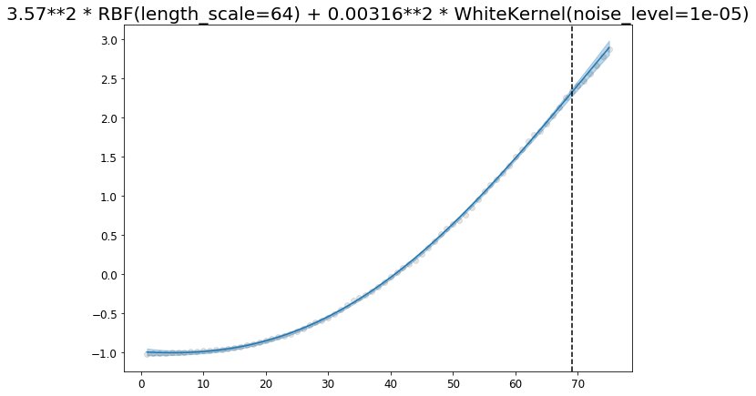

```
Log Marginal Likelihood:77.45271885940377
Average distance test-prediction in units of sigma: 0.019766500188627852
```

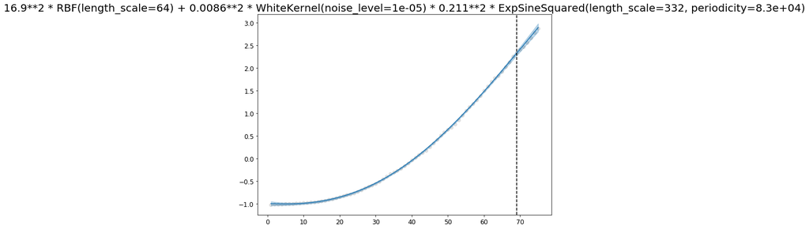

```
Log Marginal Likelihood:77.4527190662532
Average distance test-prediction in units of sigma: 0.019763393016534316
It seems that there's no periodicity
```

```python
#        dominating trend  +   statistic noise
k1 = 5 * RBF(length_scale=10)  + 0.1 * WhiteKernel()

fit_and_predict(k1, train_X, train_Y, test_X, test_Y)
periodicity_term =  0.05 * ExpSineSquared(length_scale=0.1,periodicity=7)
k2 = k1 * periodicity_term
fit_and_predict(k2, train_X, train_Y, test_X, test_Y)

print("It seems that there's no periodicity")
```

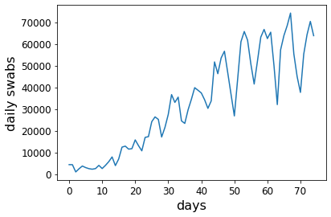

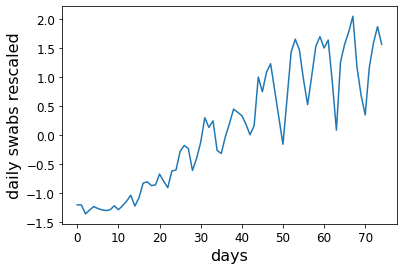

```
0.11159820930935109 1.0505222000626457
2.6122894697062506e-17 1.0000000000000002
```

```python
daily = cumulative_to_daily(raw_tamponi)
plot(daily)
plt.xlabel("days")
plt.ylabel("daily swabs")
plt.show()

train_X, train_Y, test_X, test_Y = scale(daily)
daily = np.hstack((train_Y,test_Y))

plot(range(tot_size), list(train_Y) + list(test_Y))
plt.xlabel("days")
plt.ylabel("daily swabs rescaled")
plt.show()

print(np.mean(daily), np.var(daily))
print(np.mean(train_Y), np.var(train_Y))
```

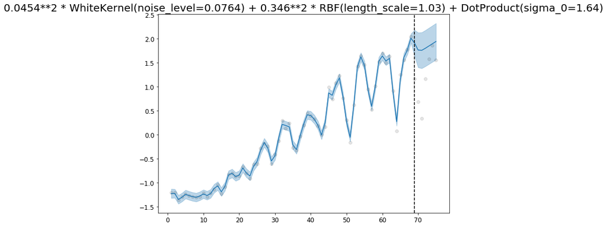

```
Log Marginal Likelihood:-18.53516793171938
Average distance test-prediction in units of sigma: 0.5167067171074601
```

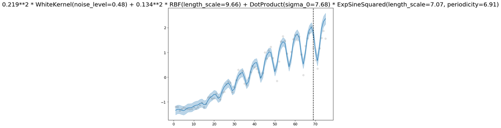

```
Log Marginal Likelihood:-2.0718366386616935
Average distance test-prediction in units of sigma: 0.5087351957421594
```

```python
k1 =  0.1 * WhiteKernel() + 5 * RBF(4) + DotProduct(5)
fit_and_predict(k1, train_X, train_Y, test_X, test_Y, seed=20)

periodicity_term = ExpSineSquared(length_scale=2,periodicity=7)

k2 = 0.1 * WhiteKernel() + 5 * (RBF(4) + DotProduct(5)) * periodicity_term
res_gp = fit_and_predict(k2, train_X, train_Y, test_X, test_Y, seed=20)
```

The cost of introducing the periodic term is that we are imposing a fixed period of the oscillations, due to weekends. This assumption fails because the oscillations caused by the weekend are negligible w.r.t. ones caused by "note_it" variable: a lot of data is affected by a bias.

Since a lot of times regions aggregate unreported cases in a single day, the oscillations are probably caused mainly by this aggregation of data in time

## Deaths:

## Dataset Preparation

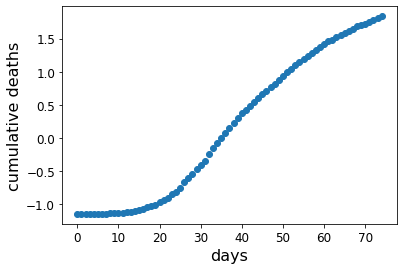

```python
scaler = StandardScaler()

#constructing data for model predicting swabs from date
unscaled_deaths = data["deceduti"].values

train_X, train_Y, test_X, test_Y = scale(unscaled_deaths)
deaths = np.hstack((train_Y,test_Y))
plot(deaths, 'o')
plt.xlabel("days")
plt.ylabel("cumulative deaths")
plt.show()
```

# Cumulative deaths

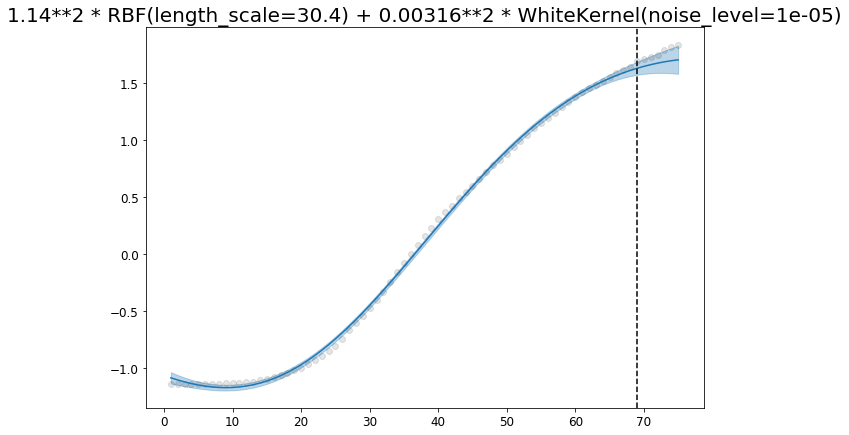

```
Log Marginal Likelihood:74.73593791925339
Average distance test-prediction in units of sigma: 0.10197348136832873
```

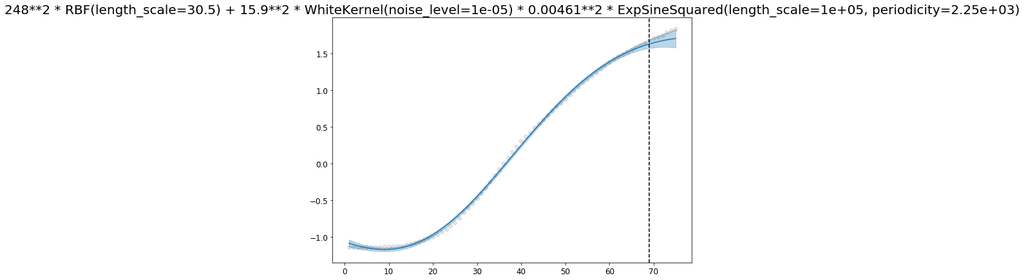

```
Log Marginal Likelihood:74.73577681485051
Average distance test-prediction in units of sigma: 0.10250756915552828
It seems that there's no periodicity
```

```python
#        dominating trend  +   statistic noise
k1 = 5 * RBF(length_scale=10)  + 0.1 * WhiteKernel()

fit_and_predict(k1, train_X, train_Y, test_X, test_Y)
periodicity_term =  0.05 * ExpSineSquared(length_scale=0.1,periodicity=7)
k2 = k1 * periodicity_term
fit_and_predict(k2, train_X, train_Y, test_X, test_Y)

print("It seems that there's no periodicity")
```

```
243
```

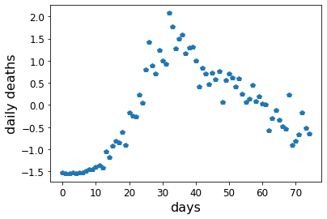

```python
daily_death = cumulative_to_daily(unscaled_deaths)

print(daily_death[-1])
train_X, train_Y, test_X, test_Y = scale(daily_death)
daily_death_scaled = np.hstack((train_Y,test_Y))
plot(daily_death_scaled, 'p')
plt.xlabel("days")
plt.ylabel("daily deaths")
plt.show()
```

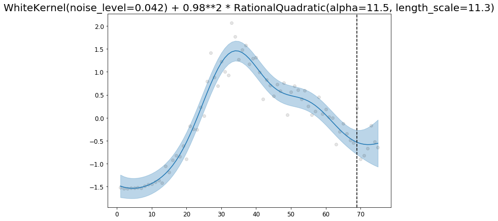

```
Log Marginal Likelihood:-12.771195946513991
Average distance test-prediction in units of sigma: 0.1627954660615865
```

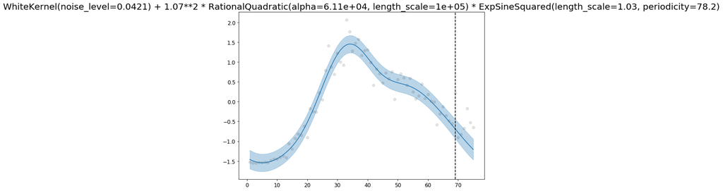

```
Log Marginal Likelihood:-12.31627093870047
Average distance test-prediction in units of sigma: 0.53319826098331
```

```python
k1 = WhiteKernel() + 5 * RationalQuadratic(1,1)
fit_and_predict(k1, train_X, train_Y, test_X, test_Y, seed= 0)

periodicity_term = ExpSineSquared(length_scale=2,periodicity=7)

k2 = WhiteKernel() + 5 * RationalQuadratic(1,1) * periodicity_term
res_gp = fit_and_predict(k2, train_X, train_Y, test_X, test_Y, seed=0)
```

## Just out of curiosity

Let's see when a model would predict 0 contagion in my province

```python
region = pd.read_csv("https://raw.githubusercontent.com/pcm-dpc/COVID-19/master/dati-province/dpc-covid19-ita-province.csv")

milan = region[region["sigla_provincia"] == "MI"]
daily_milan = cumulative_to_daily(milan["totale_casi"].values)
```

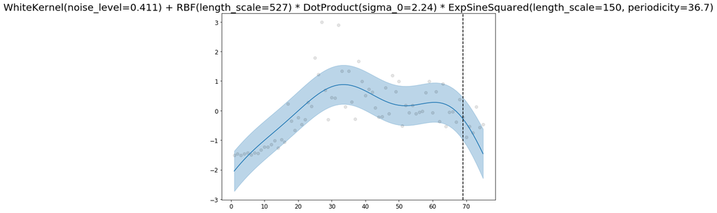

```
Log Marginal Likelihood:-79.23839870683646
Average distance test-prediction in units of sigma: 0.06673288669964915
```

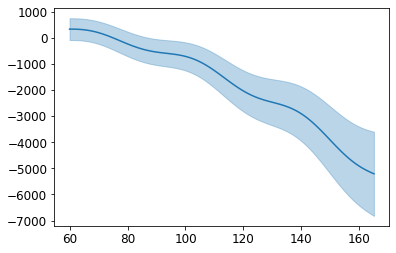

```python
train_X, train_Y, test_X, test_Y,scaler = scale(daily_milan, return_scaler=True)

k1 = WhiteKernel() + RBF(10) * DotProduct(10) * periodicity_term
res_gp = fit_and_predict(k1, train_X, train_Y, test_X, test_Y, seed=0)

prediction_time = 90
X = array(range(60, milan.shape[0] + prediction_time + 1))

pred_y, pred_std = res_gp.predict(X.reshape(-1,1), return_std=True)

pred_y = scaler.inverse_transform(pred_y).flatten()
pred_std = scaler.inverse_transform(pred_std).flatten()

l, = plt.plot(X, pred_y)
plt.fill_between(X,
                 pred_y + pred_std,
                 pred_y - pred_std,
                 color=l.get_color(), alpha=0.3)
plt.show()
```

```python
total_len = pred_y.shape[0] + 60
sure_end = total_len - (pred_y[pred_y + 3 * pred_std < 0 ].shape[0])
first_end = total_len - (pred_y[pred_y - 3 * pred_std < 0 ].shape[0])

print("last possible day of 0 contagion: day " + str(sure_end))
print("first possible day of 0 contagion: day " + str(first_end))

first = milan["data"].iloc[0]
print("day 1st is " + first)

print("0 contagion 'for sure' on 22th of July")
print("0 contagion 'at least' has already passed")
```

```
last possible day of 0 contagion: day 149
first possible day of 0 contagion: day 60
day 1st is 2020-02-24T18:00:00
0 contagion 'for sure' on 22th of July
0 contagion 'at least' has already passed
```

Of course, this model is very simple and oblivious that we reopened lots of workplaces on 4th of May and as we can see the variance is very high, so I'd not consider this a good estimate